# UML

Sequenzdiagramme, Zustandsdiagramme

## Sequenzdiagramm: Nachrichten

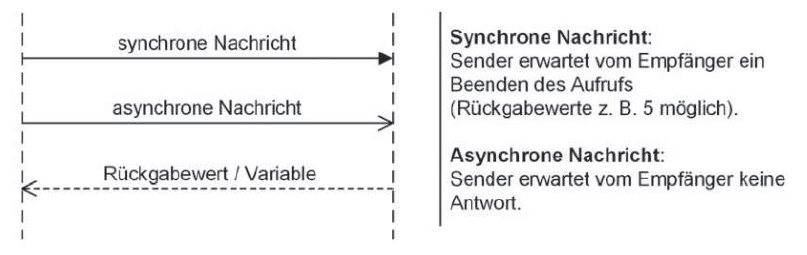

### Sequenz-diagramm: Lebenslinien

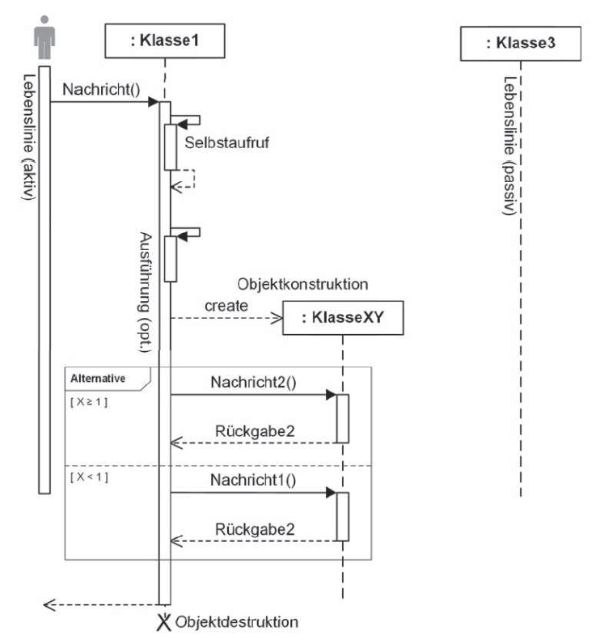

## Sequenzdiagramm: Bedingungen

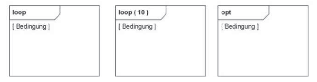

### Sequenz-diagramm: Überblick

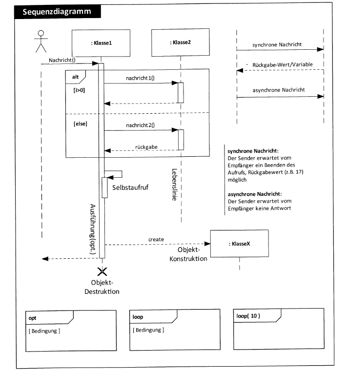

## Sequenzdiagramm: Beispiel

```
sequenceDiagram
    actor Benutzer
    participant LoginController
    participant Datenbank
    participant Session

    Benutzer->>LoginController: login(user,pw)
    LoginController->>Datenbank: prüfeUser(user,pw)
    Datenbank-->>LoginController: Ergebnis

    alt gültig
        LoginController->>Session: erzeugeSession()
        Session-->>LoginController: SessionID
        LoginController-->>Benutzer: Erfolg
    else ungültig
        LoginController-->>Benutzer: Fehler
    end
```

## Sequenzdiagramm: Mermaid

```
sequenceDiagram
    actor Benutzer
    participant LoginController
    participant Datenbank
    participant Session

    Benutzer->>LoginController: login(user,pw)
    LoginController->>Datenbank: prüfeUser(user,pw)
    Datenbank-->>LoginController: Ergebnis

    alt gültig
        LoginController->>Session: erzeugeSession()
        Session-->>LoginController: SessionID
        LoginController-->>Benutzer: Erfolg
    else ungültig
        LoginController-->>Benutzer: Fehler
    end
```

## Sequenzdiagramm: Zusammenfassung

**Was stellt ein Sequenzdiagramm in UML dar und in welchen Szenarien wird es typischerweise verwendet?**

- Ein **Sequenzdiagramm** in UML zeigt die **Interaktionen zwischen Objekten** in der **Reihenfolge**, in der sie auftreten
- Es besteht aus
  - einer Reihe von vertikalen **“Lebenslinien”**, die Objekte oder Klassen repräsentieren, und
  - horizontalen **“Nachrichten”**, die zwischen den Lebenslinien hin und her gehen
- Nachrichten sind zeitlich von oben nach unten geordnet, sodass man sehen kann, in welcher Reihenfolge die Interaktionen auftreten
- Sequenzdiagramme helfen dabei, die **dynamischen Interaktionen** in einem System darzustellen und zu analysieren

## Zustandsdiagramm

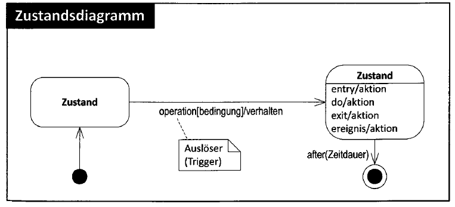

## Zustandsdiagramm: Bestellung

[output not shown]

## Zustandsdiagramm: Bestellung

```
stateDiagram-v2

    direction LR

    [*] --> Neu
    Neu --> Bestaetigt : bestellen()

    Bestaetigt --> Bezahlt : zahlung_ok()
    Bestaetigt --> Storniert : stornieren()

    Bezahlt --> Versendet : versenden()
    Versendet --> Geliefert : zugestellt()

    Geliefert --> [*]
    Storniert --> [*]
```

#### Mermaid-Code

```
stateDiagram-v2

    direction LR

    [*] --> Neu
    Neu --> Bestaetigt : bestellen()

    Bestaetigt --> Bezahlt : zahlung_ok()
    Bestaetigt --> Storniert : stornieren()

    Bezahlt --> Versendet : versenden()
    Versendet --> Geliefert : zugestellt()

    Geliefert --> [*]
    Storniert --> [*]
```

## Zustandsdiagramm: Zusammenfassung

**Erklären Sie die Verwendung des UML-Zustandsdiagramms zur Modellierung von Verhalten in einem System.**

- **UML-Zustandsdiagramm** bildet **Lebenszyklus** eines Objekts ab durch Darstellung seiner verschiedenen **Zustände und Übergänge**
- Besonders nützlich bei der Modellierung von **Objekten, die komplexes Verhalten aufweisen** und viele verschiedene Zustände haben können
- Was geben Zustandsdiagramme wieder?
  - den aktuellen **Zustand** eines Objekts
  - die **Aktionen**, die beim **Eintritt**, während des **Verweilen**s und beim **Verlassen des Zustands** durchgeführt werden
  - **Bedingungen für den Übergang** zu anderen Zuständen
- Ermöglichen die Darstellung und das Verständnis komplexer **verhaltensbasierter Systeme**

## Wann welches Diagramm?

| Diagramm | Zeigt | Kategorie | Typische Fragestellung |
| --- | --- | --- | --- |
| Aktivitäts-diagramm | Abläufe, Workflows | Verhaltens-diagramm | “Wie läuft der Prozess ab?” |
| Anwendungs-falldiagramm | Funktionen und Akteure | Verhaltens-diagramm | “WAS kann das System? Wer nutzt es?” |
| Klassen-diagramm | Statische Struktur | Struktur-diagramm | “Welche Klassen gibt es und wie hängen sie zusammen?” |
| Sequenz-diagramm | Zeitlicher Nachrichtenaustausch | Verhaltens-diagramm | “In welcher Reihenfolge kommunizieren die Objekte?” |
| Zustands-diagramm | Zustände und Übergänge | Verhaltens-diagramm | “Welche Zustände hat ein Objekt?” |

## Häufige UML-Fehler

| Fehler | Korrektur |
| --- | --- |
| Aggregation und Komposition verwechselt | Komposition = starke Abhängigkeit (Teil stirbt mit Ganzem) |
| Include und Extend vertauscht | Include = obligatorisch, Extend = optional |
| Klassendiagramm ohne Sichtbarkeiten | Immer +, -, # angeben |
| Sequenzdiagramm ohne Rückgabepfeile | Synchrone Aufrufe brauchen eine Antwort (gestrichelter Pfeil) |
| Zustandsdiagramm ohne Start- / Endzustand | Start (●) und Ende (◉) gehören immer dazu |
| Aktivitäten im Use-Case-Diagramm | Use Cases beschreiben FUNKTIONEN, keine Ablaufschritte |

[©torange.biz](https://torange.biz/cup-coffee-30851) CC-BY 4.0

**Viel Erfolg!**

Zurück zur Übersicht LF11a